# Project 2: Data Mining, Classification, Prediction

SDS322E

12/12/2021

# Mining, Classification, Prediction

## Paul Paredes (pjp849)

### Introduction

```r
library(tidyverse)

restaurant_data = read_csv("https://vincentarelbundock.github.io/Rdatasets/csv/causaldata/restaurant_inspections.csv")

newrestaurant = restaurant_data %>% slice(1:2500)

head(newrestaurant)
```

```
## # A tibble: 6 x 6
##      X1 business_name            inspection_score  Year NumberofLocatio… Weekend
##   <dbl> <chr>                               <dbl> <dbl>            <dbl> <lgl>
## 1     1 MCGINLEYS PUB                          94  2017                9 FALSE
## 2     2 VILLAGE INN #1                         86  2015               66 FALSE
## 3     3 RONNIE SUSHI 2                         80  2016               79 FALSE
## 4     4 FRED MEYER - RETAIL FISH               96  2003               86 FALSE
## 5     5 PHO GRILL                              83  2017               53 FALSE
## 6     6 TACO KING #2                           95  2008               89 FALSE
```

```r
nrow(newrestaurant)
```

```
## [1] 2500
```

```r
newrestaurant %>% filter(Weekend == TRUE) %>% nrow()
```

```
## [1] 12
```

```r
newrestaurant %>% filter(Weekend == FALSE) %>% nrow()
```

```
## [1] 2488
```

The dataset I used was found in the list of datasets from https://vincentarelbundock.github.io/Rdatasets/datasets.html; this particular dataset was created by Louis-Ashley Camus and derived from restaurant health inspections performed in Anchorage, Alaska. business_name is the name of the restaurant or chain, inspection_score is the numerical Health Inspection Score given, Year is the year of inspection, NumberofLocations is the number of locations in Anchorage, and Weekend is a binary variable about whether or not the inspection was performed on a weekend (TRUE if the answer is affirmative, False otherwise). X1 is just the row number.

The dataset was cut down since there were too many observations for cluster analysis, PCA, etc. to handle. There are 2,500 observations in total. Out of these observations, 12 had a health inspection on a weekend (TRUE), and 2,488 did not (FALSE).

### Cluster Analysis

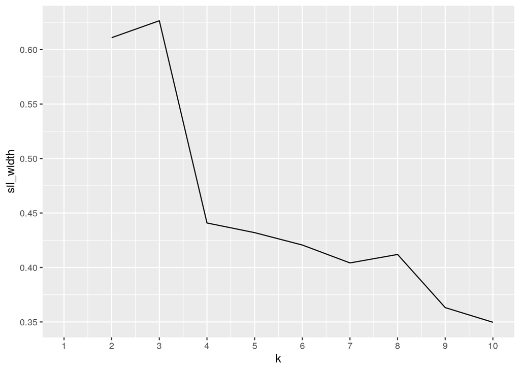

```r
library(cluster)
library(ggplot2)
library(GGally)

pam_dat <- newrestaurant %>% select(inspection_score, Year, NumberofLocations)
sil_width <- vector()
for (i in 2:10) {
    pam_fit <- pam(pam_dat, k = i)
    sil_width[i] <- pam_fit$silinfo$avg.width
}
ggplot() + geom_line(aes(x = 1:10, y = sil_width)) + scale_x_continuous(name = "k",
    breaks = 1:10)  #greatest sil_width at k=3
```

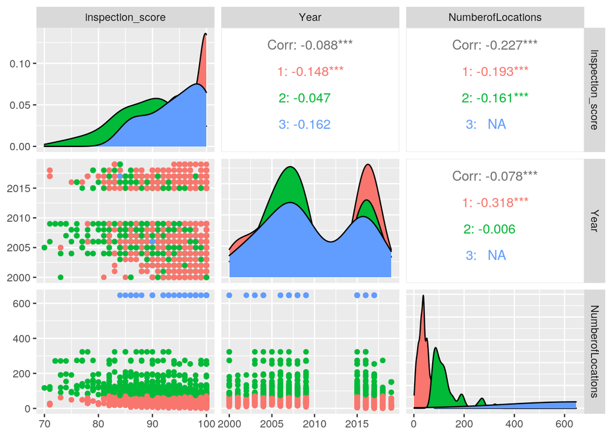

```r
pam1 <- pam_dat %>% pam(k = 3)
newrestaurant %>% mutate(cluster = as.factor(pam1$clustering)) %>%
    ggpairs(columns = c("inspection_score", "Year", "NumberofLocations"),
        aes(color = cluster))
```

```r
pam1$silinfo$avg.width
```

```
## [1] 0.6264864
```

NumberofLocations and inspection_score have the strongest overall correlation at -0.227. All three variables used (inspection_score, Year, and NumberofLocations) have negative correlations with each other. The average silhouette width is 0.6264864, which indicates that a reasonable cluster solution has been found.